# Parcial1

SANTIAGO LOPEZ Y DIEGO MARIN

3/25/2022

## Parcial 1

### Punto 1

La tabla mostrada contiene valores de poblacion, en cientos de miles, de las diez ciudades mas pobladas de cuatro paises en el anio 1967:

| Argentina | EE.UU. | Holanda | Japon |
| --- | --- | --- | --- |
| 29.66 | 77.81 | 8.68 | 110.21 |
| 7.61 | 35.50 | 7.31 | 32.14 |
| 6.35 | 24.79 | 6.02 | 18.88 |
| 4.10 | 20.02 | 2.64 | 16.38 |
| 3.80 | 16.70 | 1.75 | 13.37 |
| 2.75 | 9.39 | 1.72 | 11.92 |
| 2.70 | 9.38 | 1.51 | 10.71 |
| 2.69 | 8.76 | 1.42 | 7.80 |
| 2.51 | 7.63 | 1.31 | 7.70 |
| 2.44 | 7.50 | 1.29 | 7.00 |

#### A.Construya un box-plot e identifique los puntos extremos. Cuales son las caracteristicas mas sobresalientes? Hay outliers?

```r
## creqcion de los vectores con los datos recolectados por pais
argentina = c(29.66, 7.61, 6.35, 4.10, 3.80, 2.75, 2.70, 2.69, 2.51, 2.44)
eeuu = c(77.81, 35.50, 24.79, 20.02, 16.70, 9.39, 9.38, 8.76, 7.63, 7.50)
holanda = c(8.68, 7.31, 6.02, 2.64, 1.75, 1.72, 1.51, 1.42, 1.31, 1.29)
japon = c(110.21, 32.14, 18.88, 16.38, 13.37, 11.92, 10.71, 7.80, 7.70, 7.00)
```

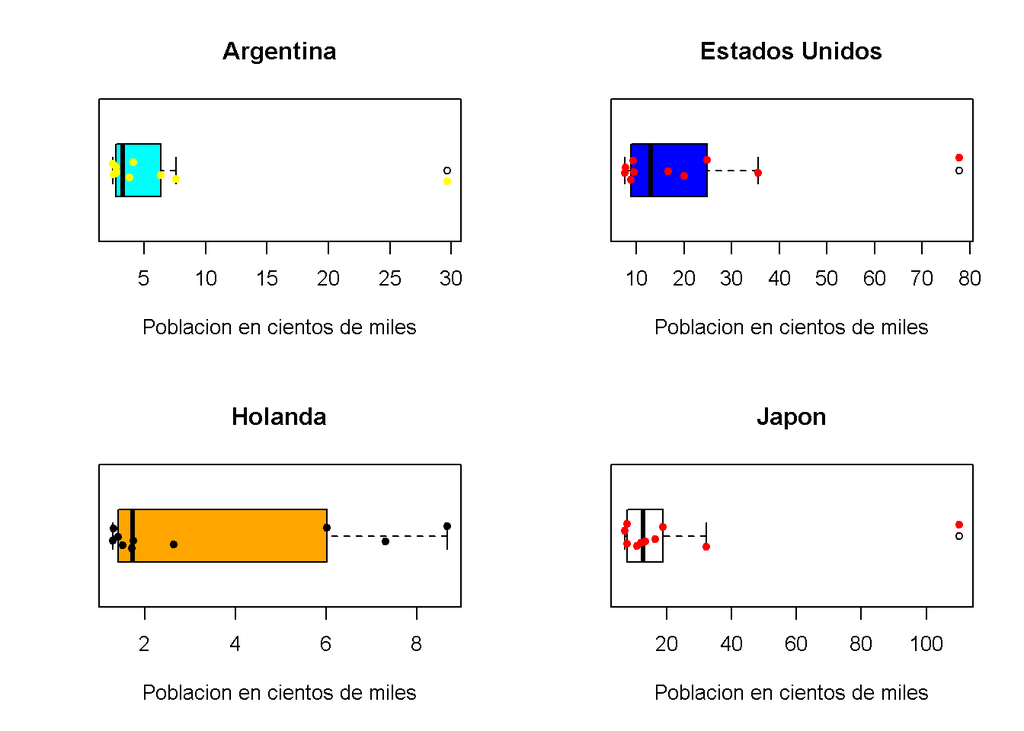

#### B. Compare los centros de cada poblacion, sus dispersiones y su simetria. Cual es el pais mas homogeneamente habitado? Cuales son las caracteristicas mas sobresalientes? Hay outliers?

```r
## medias de los 4 paises
mediaArgentina = mean(argentina)
mediaEEUU = mean(eeuu)
mediaHolanda = mean(holanda)
mediaJapon = mean(japon)
## mediana de los 4 pais
medianaArgentina= median(argentina)
medianaEEUU= median(eeuu)
medianaHolanda= median(holanda)
medianaJapon= median(japon)
## Varuianza de los 4 pais
varArgentina = var(argentina)
varEEUU = var(eeuu)
varHolanda = var(holanda)
varJapon = var(japon)
## Desviacion Estandar de los 4 paises
desArgentina= sd(argentina)
desEEUU= sd(eeuu)
desHolanda= sd(holanda)
desJapon= sd(japon)
## coeficiente de relacion de los 4 paises
cvArgentina= (desArgentina/mediaArgentina)*100
cvEEUU= (desEEUU/mediaEEUU)*100
cvHolanda= (desHolanda/mediaHolanda)*100
cvJapon= (desJapon/mediaJapon)*100
```

| Datos Estadisticos | Argentina | EE.UU. | Holanda | Japon |
| --- | --- | --- | --- | --- |
| Media | 6.461 | 21.748 | 3.365 | 23.611 |
| Mediana | 3.275 | 13.045 | 1.735 | 12.645 |
| Moda | amodal | amodal | amodal | amodal |
| Varianza | 69.566 | 471.831 | 8.05 | 981.540 |
| Desviacion Estandar | 8.340 | 21.721 | 2.837 | 31.329 |
| Coeficiente de variacion | 129.092 | 99.879 | 84.318 | 132.690 |
| Simetria | Positiva | Positiva | Positiva | Positiva |

##### - Estados Unidos tiene un pormedio de 2.174,8 mil habitantes con una desviacion estadar de mas o menos 2.172,1 mil habitantes y una simetria positiva con respecto a sus medidas de tendencia central, Estados Unidos presenta un dato atipico de 7.781 mil habitantes.

##### - Holanda tiene un pormedio de 336,5 mil habitantes con una desviacion estadar de mas o menos 283,7 mil habitantes y una simetria positiva con respecto a sus medidas de tendencia central, Holanda no presenta ningun dato atipico.

##### - Japon tiene un pormedio de 2.361,1 mil habitantes con una desviacion estadar de mas o menos 3.132,9 mil habitantes y una simetria positiva con respecto a sus medidas de tendencia central, Japon presenta un dato atipico de 11.021 mil habitantes.

#### Con respecto al coeficiente de variacion se puede concluir que el Pais mas homogeneamente habitado es Holanda, pues tiene el coeficiente de variacion mas bajo, lo que quiere decir, que los datos tienen poca variacion

### Punto 2

Avianca se encuentra estudiando la situacion de venta de puesto en el vuelo Armenia – Bogota puesto que ha identificado que el 2% de las personas que reservaron puesto, no se presentan a la hora del embarque. Teniendo en cuenta que el avion A320 utilizado en esta ruta tiene una capacidad para 180 pasajeros, la empresa decide vender 181 tiquetes. Cual es la probabilidad de que todas las personas que llegan a embarque puedan tener su silla asegurada y no se presenten quejas por “sobre-vender” sillas ante la aeronautica civil? Asuma que las llegadas de los pasajeros siguen una distribucion Poisson

```r
## se sabe que el 98% de las personas que reservan el vuelo de Armenia - Bogota se presentan a la hora de emabarque, entonces
lambda2= 180 * 0.98
## probabilidad de que x<= 180, siendo X la cantidad de personas embarcando al avion
ppois(180, lambda = lambda2, lower.tail = TRUE)
```

```
## [1] 0.6255245
```

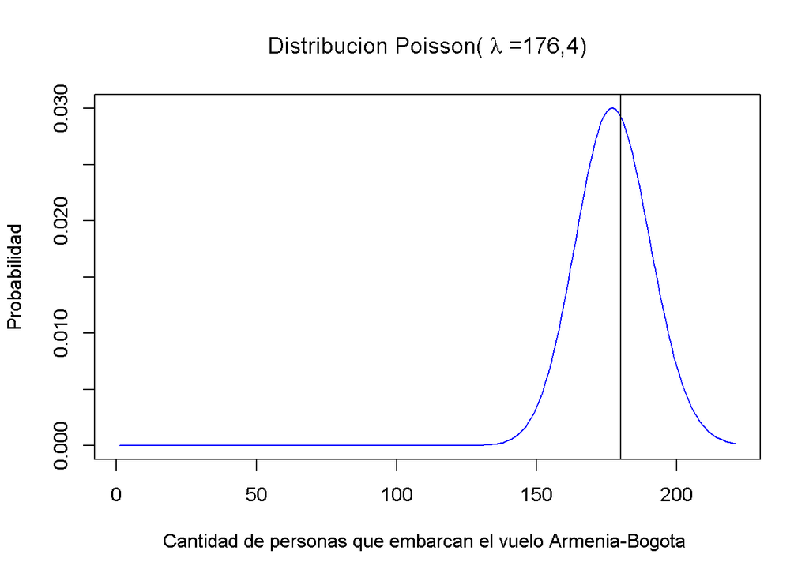

#### La probabilidad de que todas las personas que llegan a embarcar tengan su silla asegurada y no presenten quejas por “sobre-vender” sillas ante la aeronautica civil es de 0.6255

### Punto 3

En la planta envasadora de Coca-Cola FEMSA ubicada en Tocancipa se realiza el embotellado de la Coca-Cola presentacion de 400 mL (en promedio), con una desviacion estandar de 5 mL (mililitros). Si se sabe por experiencia que este proceso de embotellado sigue una distribucion normal, y tambien se sabe que todo producto con mas de 415 mL es declarado como NO CONFORME. Determine el porcentaje de las botellas de gaseosa que son declaradas producto NO CONFORME.

```r
## X es la cantidad de mL en las botellas envasadas en la planta de Coca-Cola FEMSA en Tocancipa
##teniendo como media
mu= 400
## y desviacion estandar
sigma= 5

pnorm(415, mu , sigma , lower.tail = FALSE)
```

```
## [1] 0.001349898
```

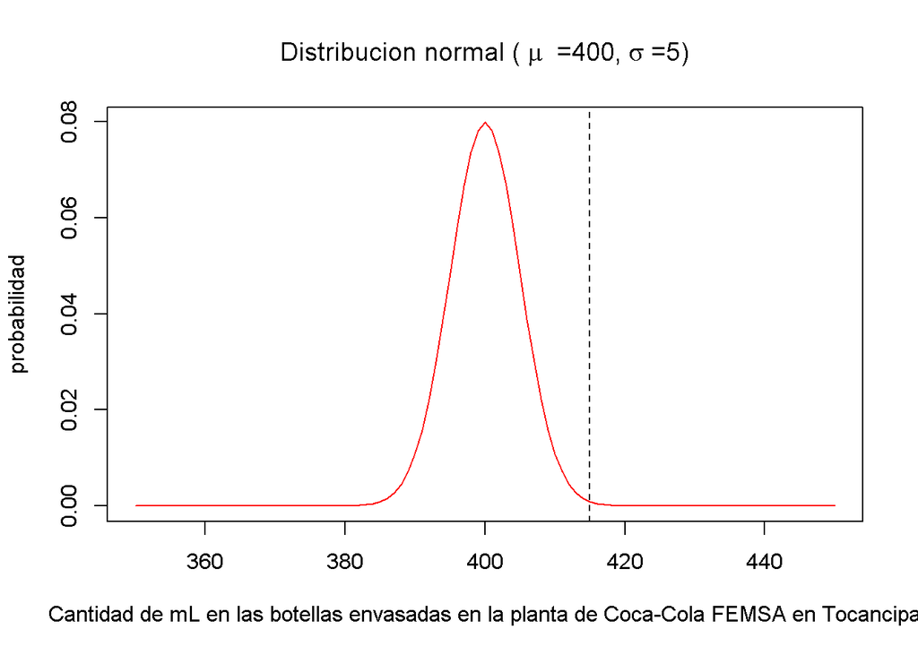

#### El porcentaje de las botellas de gaseosa Coca-Cola en presentacion de 400 mL envasadas en Tocancipa que son declaradas como NO CONFORMES es de 0,1349%